# Assignment 1 | 624 |

Kohl Kinning

## Part 1 | SF-Seq read quality score distributions

Kohl 10_2G_both 17_3E_fox

The demultiplexed .fastq files are here: /projects/bgmp/2017_sequencing/demultiplexed/

1. *Using FastQC on Talapas, produce plots of quality score distributions for forward and reverse reads. Also, produce plots of the per-base N content.*

### FastQC output

#### 10_2G_both_R1

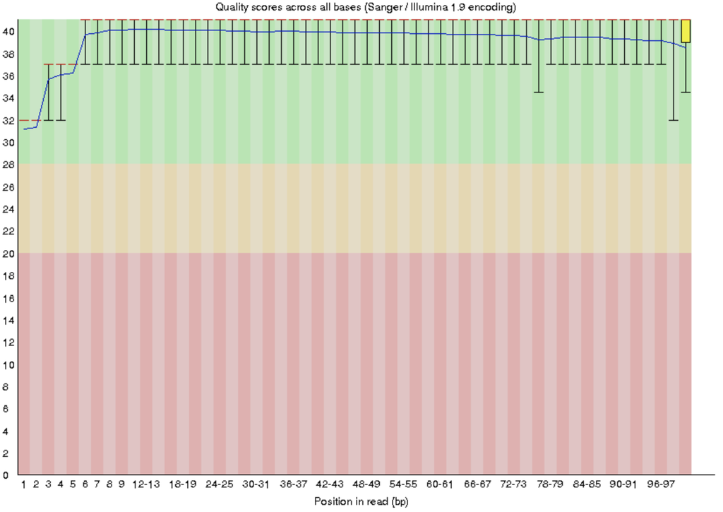

#### 10_2G_both_R2

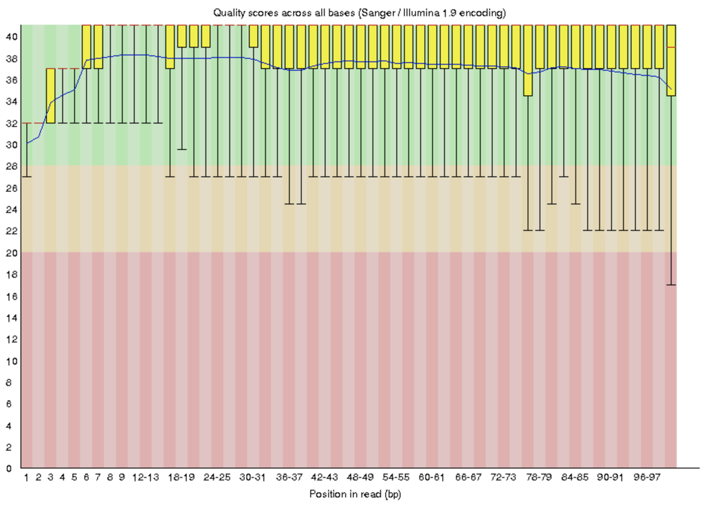

#### 17_3E_fox_R1

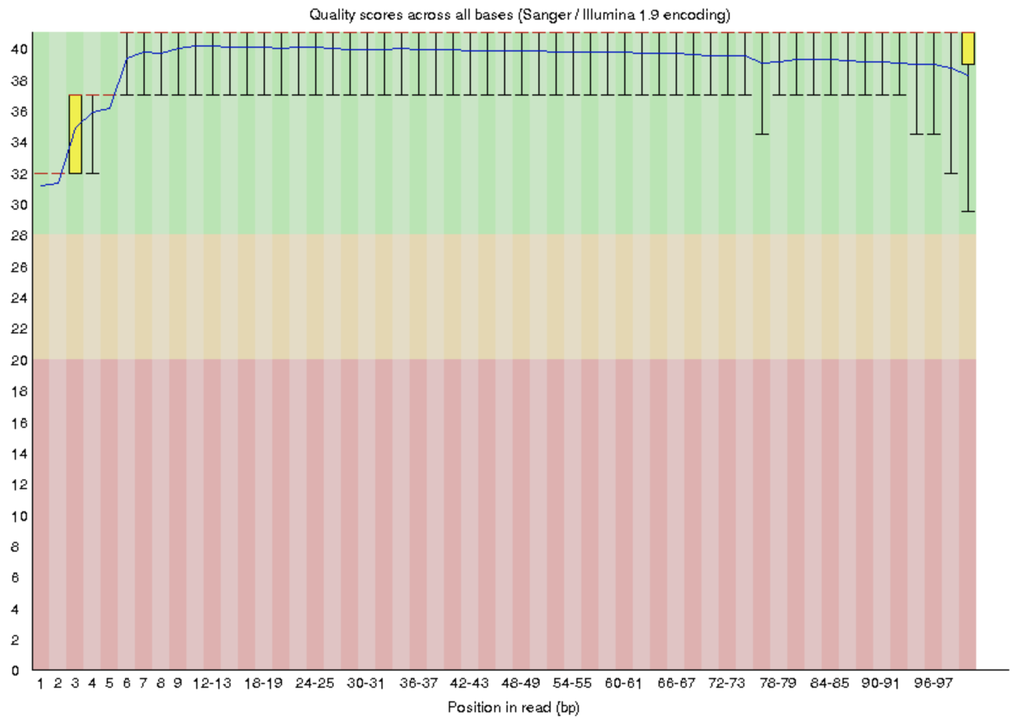

#### 17_3E_fox_R2

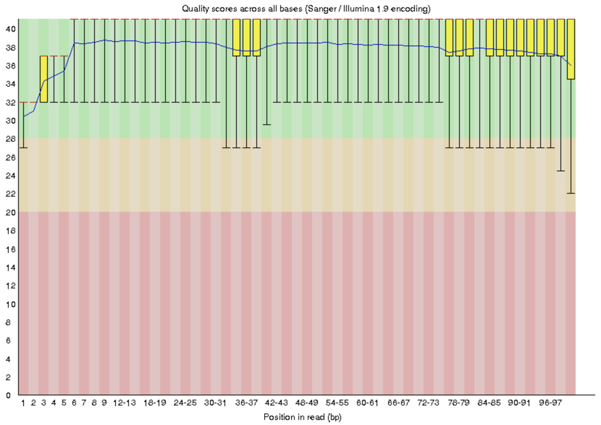

```r
R1_10_2G = read.delim("/Users/kohl/Documents/GradSchool/semester2/GenomicsLab/Assignments/sf-seq-qaa-kohlkopf/Part_1/q1.out", header = TRUE, sep = "\t")
R2_10_2G = read.delim("/Users/kohl/Documents/GradSchool/semester2/GenomicsLab/Assignments/sf-seq-qaa-kohlkopf/Part_1/q2.out", header = TRUE, "\t")
R1_17_3E = read.delim("/Users/kohl/Documents/GradSchool/semester2/GenomicsLab/Assignments/sf-seq-qaa-kohlkopf/Part_1/q3.out", header = TRUE, sep = "\t")
R2_17_3E = read.delim("/Users/kohl/Documents/GradSchool/semester2/GenomicsLab/Assignments/sf-seq-qaa-kohlkopf/Part_1/q4.out", header = TRUE, sep = "\t")
```

```r
plot(R1_10_2G$BPPosition,
     R1_10_2G$MeanScore,
     type="n",
     ylim = range(0, 45),
     main = "10_2G_both R1 Read Quality",
     ylab = "Quality Score",
     xlab = "Base Position",
     xaxt = "n")
rect(-4, -4, 104, 20, col = rgb(222, 177, 178, 100, maxColorValue = 255), border = NA)
```

```r
rect(-4, 20, 104, 28, col = rgb(228, 214, 178, 100, maxColorValue = 255), border = NA)
rect(-4, 28, 104, 48, col = rgb(183, 224, 178, 100, maxColorValue = 255), border = NA)
```

```r
grid(NULL, 0)
arrows(R1_10_2G$BPPosition,
       R1_10_2G$MeanScore-R1_10_2G$StDev,
       R1_10_2G$BPPosition,
       R1_10_2G$MeanScore+R1_10_2G$StDev,
       length=0.01,
       angle=90,
       code=3)
```

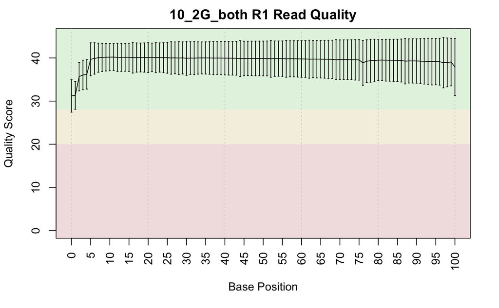

```r
lines(R1_10_2G$BPPosition, R1_10_2G$MeanScore)
axis(1, xaxp=c(0, 100, 20), las=2)
```

```r
plot(R2_10_2G$BPPosition,
     R2_10_2G$MeanScore,
     type="n",
     ylim = range(0, 45),
     main = "10_2G_both R2 Read Quality",
     ylab = "Quality Score",
     xlab = "Base Position",
     xaxt = "n")
rect(-4, -4, 104, 20, col = rgb(222, 177, 178, 100, maxColorValue = 255), border = NA)
```

```r
rect(-4, 20, 104, 28, col = rgb(228, 214, 178, 100, maxColorValue = 255), border = NA)
rect(-4, 28, 104, 48, col = rgb(183, 224, 178, 100, maxColorValue = 255), border = NA)
```

```r
grid(NULL, 0)
arrows(R2_10_2G$BPPosition,
       R2_10_2G$MeanScore-R2_10_2G$StDev,
       R2_10_2G$BPPosition,
       R2_10_2G$MeanScore+R2_10_2G$StDev,
       length=0.01,
       angle=90,
       code=3)
```

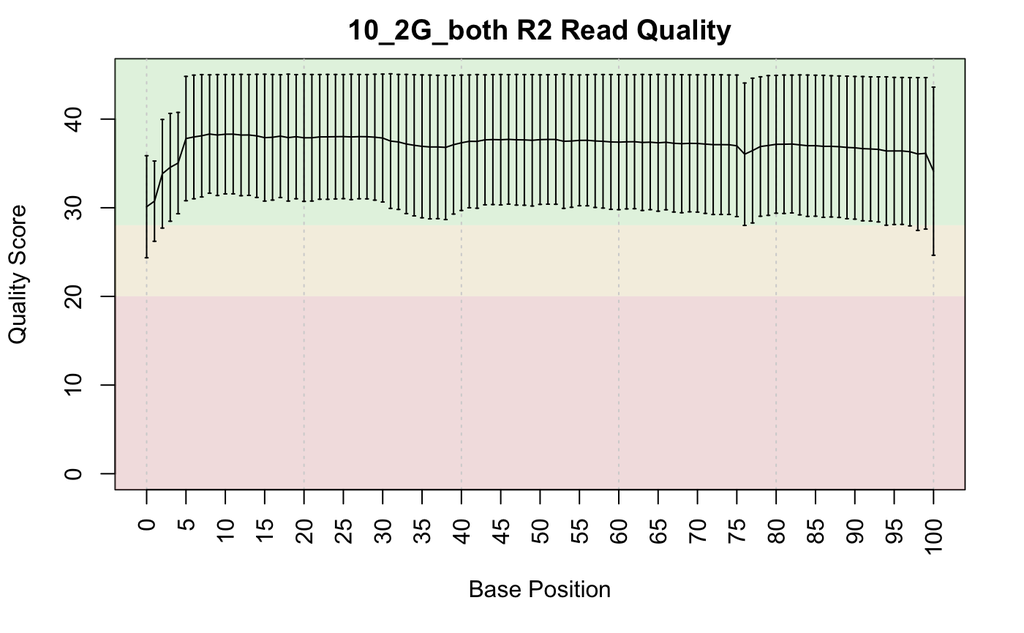

```r
lines(R2_10_2G$BPPosition, R2_10_2G$MeanScore)
axis(1, xaxp=c(0, 100, 20), las=2)
```

```r
plot(R1_17_3E$BPPosition,
     R1_17_3E$MeanScore,
     type="n",
     ylim = range(0, 45),
     main = "17_3E_fox R1 Read Quality",
     ylab = "Quality Score",
     xlab = "Base Position",
     xaxt = "n")
rect(-4, -4, 104, 20, col = rgb(222, 177, 178, 100, maxColorValue = 255), border = NA)
```

```r
rect(-4, 20, 104, 28, col = rgb(228, 214, 178, 100, maxColorValue = 255), border = NA)
rect(-4, 28, 104, 48, col = rgb(183, 224, 178, 100, maxColorValue = 255), border = NA)
```

```r
grid(NULL, 0)
arrows(R1_17_3E$BPPosition,
       R1_17_3E$MeanScore-R1_17_3E$StDev,
       R1_17_3E$BPPosition,
       R1_17_3E$MeanScore+R1_17_3E$StDev,
       length=0.01,
       angle=90,
       code=3)
```

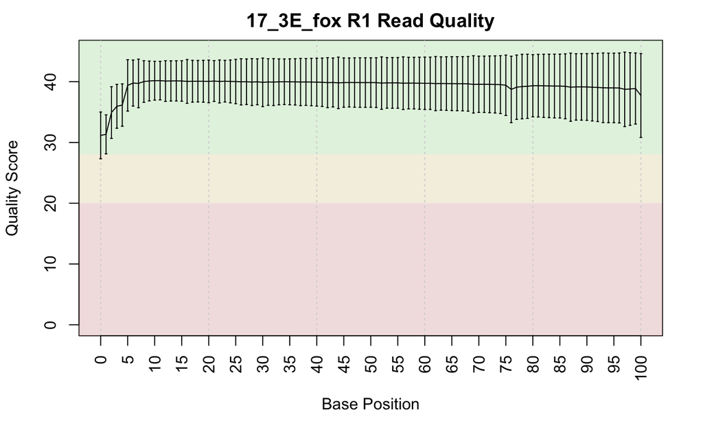

```r
lines(R1_17_3E$BPPosition, R1_17_3E$MeanScore)
axis(1, xaxp=c(0, 100, 20), las=2)
```

```r
plot(R2_17_3E$BPPosition,
     R2_17_3E$MeanScore,
     type="n",
     ylim = range(0, 45),
     main = "17_3E_fox R2 Read Quality",
     ylab = "Quality Score",
     xlab = "Base Position",
     xaxt = "n")
rect(-4, -4, 104, 20, col = rgb(222, 177, 178, 100, maxColorValue = 255), border = NA)
```

```r
rect(-4, 20, 104, 28, col = rgb(228, 214, 178, 100, maxColorValue = 255), border = NA)
rect(-4, 28, 104, 48, col = rgb(183, 224, 178, 100, maxColorValue = 255), border = NA)
```

```r
grid(NULL, 0)
arrows(R2_17_3E$BPPosition,
       R2_17_3E$MeanScore-R2_17_3E$StDev,
       R2_17_3E$BPPosition,
       R2_17_3E$MeanScore+R2_17_3E$StDev,
       length=0.01,
       angle=90,
       code=3)
```

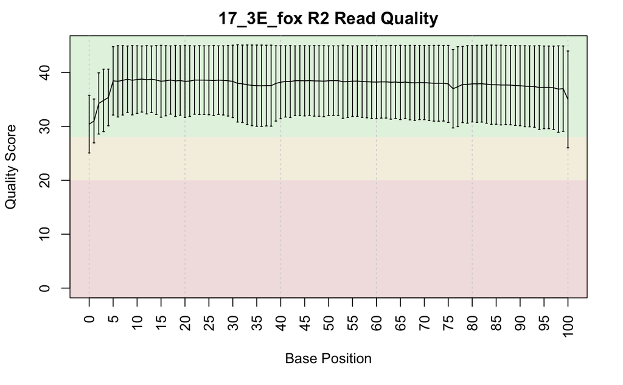

```r
lines(R2_17_3E$BPPosition, R2_17_3E$MeanScore)
axis(1, xaxp=c(0, 100, 20), las=2)
```

## Part 2 | Adaptor trimming comparison

3. *Look into the adaptor trimming options for `cutadapt`, `process_shortreads`, and `Trimmomatic` (all on Talapas), and briefly describe the differences. Pick one of these to properly trim adapter sequences. Use default settings. What proportion of reads (both forward and reverse) was trimmed?*
   - **cutadapt:** cutadapt is written in python. The reverse complement is *not* automatically searched. All reads from input.fastq are written to output.fastq with the adapter sequence removed. Adapter matching is error-tolerant. Multiple adapter sequences can be given (use further -a options), but only the best-matching adapter will be removed.
   - **process_shortreads:** process_shortreads is part of the Stacks program. It is written in C++ and Perl. Demultiplexing is supported. This program discards low quality reads unless their retention is specified as an option.
   - **Trimmomatic:** trimmomatic is a program written in java. A particular strength of Trimmomatic is that it retains the pairing of reads. It provides four output files when trimming paired end reads: trimmed paired and unpaired for both forward and reverse reads. Demultiplexing is supported.

### Trimmomatic

#### Commands

Run trimmomatic on Talapas. Specify inputs, outputs, phred33, and the file with the adapter sequences. Remove leading low quality or N bases (below quality 3) (LEADING:3), remove trailing low quality or N bases (below quality 3) (TRAILING:3), scan the read with a 4-base wide sliding window, cutting when the average quality per base drops below 15 (SLIDINGWINDOW:4:15), and drop reads below the 36 bases long (MINLEN:36). Perform the trimming for 10_2G_both and 17_3E_fox.

##### 10_2G_both

```bash
$ java -jar $EBROOTTRIMMOMATIC/trimmomatic-0.36.jar PE ../10_2G_both_S8_L008_R1_001.fastq ../10_2G_both_S8_L008_R2_001.fastq ../out_paired_10_2G_both_S8_L008_R1_001.fastq ../out_unpaired_10_2G_both_S8_L008_R1_001.fastq ../out_paired_10_2G_both_S8_L008_R2_001.fastq ../out_unpaired_10_2G_both_S8_L008_R2_001.fastq -phred33 ILLUMINACLIP:TruSeq3-PE.fa:2:30:10 LEADING:3 TRAILING:3 SLIDINGWINDOW:4:15 MINLEN:36
```

##### 17_3E_fox

```bash
$ java -jar $EBROOTTRIMMOMATIC/trimmomatic-0.36.jar PE ../17_3E_fox_S13_L008_R1_001.fastq ../17_3E_fox_S13_L008_R2_001.fastq ../out_paired_17_3E_fox_S13_L008_R1_001.fastq ../out_unpaired_17_3E_fox_S13_L008_R1_001.fastq ../out_paired_17_3E_fox_S13_L008_R2_001.fastq ../out_unpaired_17_3E_fox_S13_L008_R2_001.fastq -phred33 ILLUMINACLIP:TruSeq3-PE.fa:2:30:10 LEADING:3 TRAILING:3 SLIDINGWINDOW:4:15 MINLEN:36
```

#### Results

Trimmomatic stats reported. In addition to this information, four output files were created for 10_2G_both and four output files were created for 17_3E_fox.

##### 10_2G_both

```bash
Using PrefixPair: "GATCGGAAGAGCACACGTCTGAACTCCAGTCACNNNNNNNNATCTCGTATGCCGTCTTCTGCTTG" and "GATCGGAAGAGCGTCGTGTAGGGAAAGAGTGTNNNNNNNNGTGTAGATCTCGGTGGTCGCCGTATCATT"
ILLUMINACLIP: Using 1 prefix pairs, 0 forward/reverse sequences, 0 forward only sequences, 0 reverse only sequences
Input Read Pairs: 81477069 Both Surviving: 75242788 (92.35%) Forward Only Surviving: 5959764 (7.31%) Reverse Only Surviving: 152816 (0.19%) Dropped: 121701 (0.15%)
TrimmomaticPE: Completed successfully
```

##### 17_3E_fox

```bash
Using PrefixPair: "GATCGGAAGAGCACACGTCTGAACTCCAGTCACNNNNNNNNATCTCGTATGCCGTCTTCTGCTTG" and "GATCGGAAGAGCGTCGTGTAGGGAAAGAGTGTNNNNNNNNGTGTAGATCTCGGTGGTCGCCGTATCATT"
ILLUMINACLIP: Using 1 prefix pairs, 0 forward/reverse sequences, 0 forward only sequences, 0 reverse only sequences
Input Read Pairs: 11784410 Both Surviving: 11033098 (93.62%) Forward Only Surviving: 709636 (6.02%) Reverse Only Surviving: 25877 (0.22%) Dropped: 15799 (0.13%)
TrimmomaticPE: Completed successfully
```

4. *Plot the trimmed read length distributions for both forward and reverse reads (on the same plot). If necessary, consult Assignment 5 (Block 1) from Bi 623 to refresh your memory.*

Return a list of read lengths for 10_2G_R1, 10_2G_R2, 17_3E_R1, and 17_3E_R2.

```
$ awk "NR % 4 == 2" out_paired_10_2G_both_S8_L008_R1_001.fastq | awk "{print length}" |sort | uniq -c > 10_2G_R1_lengths.txt
$ awk "NR % 4 == 2" out_paired_10_2G_both_S8_L008_R2_001.fastq | awk "{print length}" |sort | uniq -c > 10_2G_R2_lengths.txt

$ awk "NR % 4 == 2" out_paired_17_3E_fox_S13_L008_R1_001.fastq  | awk "{print length}" |sort | uniq -c > 17_3E_R1_lengths.txt
$ awk "NR % 4 == 2" out_paired_17_3E_fox_S13_L008_R2_001.fastq  | awk "{print length}" |sort | uniq -c > 17_3E_R2_lengths.txt
```

```r
trimmed_len_R1_10_2G = read.table("/Users/kohl/Documents/GradSchool/semester2/GenomicsLab/Assignments/sf-seq-qaa-kohlkopf/Part_2/10_2G_R1_lengths.txt")
trimmed_len_R2_10_2G = read.table("/Users/kohl/Documents/GradSchool/semester2/GenomicsLab/Assignments/sf-seq-qaa-kohlkopf/Part_2/10_2G_R2_lengths.txt")
trimmed_len_R1_17_3E = read.table("/Users/kohl/Documents/GradSchool/semester2/GenomicsLab/Assignments/sf-seq-qaa-kohlkopf/Part_2/17_3E_R1_lengths.txt")
trimmed_len_R2_17_3E = read.table("/Users/kohl/Documents/GradSchool/semester2/GenomicsLab/Assignments/sf-seq-qaa-kohlkopf/Part_2/17_3E_R2_lengths.txt")
```

```r
colnames(trimmed_len_R1_10_2G)[1:2] = c("counts", "lengths")
colnames(trimmed_len_R2_10_2G)[1:2] = c("counts", "lengths")
plot(trimmed_len_R1_10_2G$counts~trimmed_len_R1_10_2G$lengths,
     log = "y", col = "red4",
     pch = 3, xlab = "Read Lengths",
     ylab = "log(Counts)",
     main = "Adapter-Trimmed Sequence Length Distributions 10_2G_both")
points(trimmed_len_R2_10_2G$counts~trimmed_len_R2_10_2G$lengths, col = "blue4", pch = 5)
```

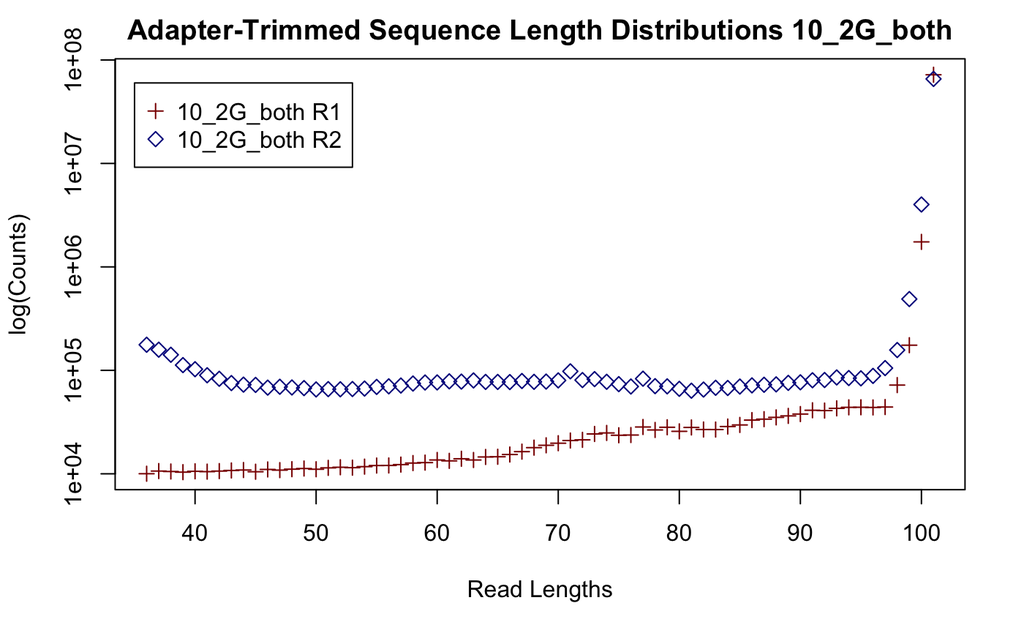

```r
legend(35,60000000,
       c("10_2G_both R1", "10_2G_both R2"),
       pch=c(3,5),
       col=c("red4", "blue4"))
```

```r
colnames(trimmed_len_R1_17_3E)[1:2] = c("counts", "lengths")
colnames(trimmed_len_R2_17_3E)[1:2] = c("counts", "lengths")
plot(trimmed_len_R1_17_3E$counts~trimmed_len_R1_17_3E$lengths,
     log = "y",
     col = "magenta4",
     pch = 3,
     xlab = "Read Lengths",
     ylab = "log(Counts)",
     main = "Adapter-Trimmed Sequence Length Distributions 17_3E_fox")
points(trimmed_len_R2_17_3E$counts~trimmed_len_R2_17_3E$lengths, col = "green4", pch = 5)
```

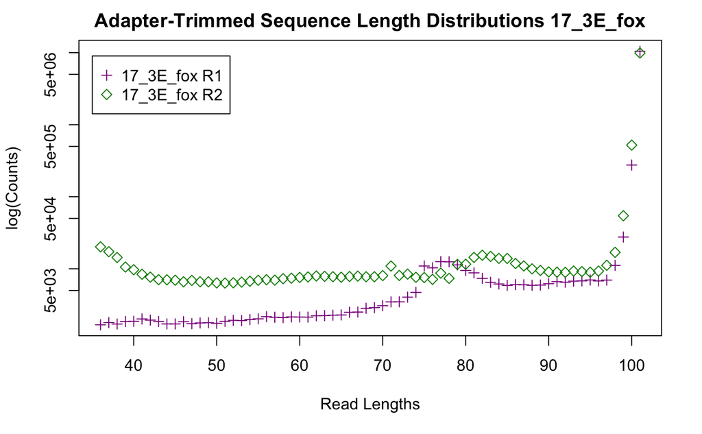

```r
legend(35,9000000,
       c("17_3E_fox R1", "17_3E_fox R2"),
       pch=c(3,5),
       col=c("magenta4", "green4"))
```

## Part 3 | rRNA reads and strand-specificity

6. *Find publicly available mouse rRNA sequences and generate a gsnap database from them. Align the SF-Seq reads to your mouse rRNA database and report the proportion of reads that likely came from rRNAs.*

Retrieve ncRNA data for *Mus musculus* from ensembl.

```bash
$ ftp ftp://ftp.ensembl.org/pub/release-90/fasta/mus_musculus/ncrna/Mus_musculus.GRCm38.ncrna.fa.gz ./
```

Utilizing UNIX commands manipulate the data to get rid of newline characters and pull out only rRNA.

```bash
$ awk "!/^>/ { printf "%s", $0; n = "\n" } /^>/ { print n $0; n = "" } END { printf "%s", n } " Mus_musculus.GRCm38.ncrna.fa > results.txt

$ grep -A 1 "rRNA" results.txt > mus_rRNA_seqs.fa
```

Build a gmap database of the *Mus musculus* rRNA. Align 10_2G_both_R1 to the database. Align 17_3E_R1 to the database.

```bash
$ gmap_build -D Mouse -d mouse_rRNA -k 15 mus_rRNA_seqs.fa

$ gsnap -D Mouse -d mouse_rRNA -B 4 -m 20 -t 8 -O --split-output aligned_10_2G -A sam ../Trim/out_paired_10_2G_both_S8_L008_R1_001.fastq
$ gsnap -D Mouse -d mouse_rRNA -B 4 -m 20 -t 8 -O --split-output aligned_17_3E -A sam ../Trim/out_paired_17_3E_fox_S13_L008_R1_001.fastq
```

Utilizing UNIX commands, generate counts of rRNA reads.

```bash
$ grep -Po "K.+:\w+:\w+:\w:\w+:\w+:\w+" aligned_10_2G.unpaired* | sort | uniq -c | wc -l
260236
$ grep -Po "K.+:\w+:\w+:\w:\w+:\w+:\w+" aligned_10_2G.nomapping | sort | uniq -c | wc -l
74984337
```

0.0034585 of the reads in the 10_2G_both sample likely came from rRNAs.

```bash
$ grep -Po "K.+:\w+:\w+:\w:\w+:\w+:\w+" aligned_17_3E.unpaired* | sort | uniq -c | wc -l
446591
$ grep -Po "K.+:\w+:\w+:\w:\w+:\w+:\w+" aligned_17_3E.nomapping | sort | uniq -c | wc -l
10587694
```

0.040473 of the reads in the 17_3E_fox sample likely came from rRNAs.

7. *Demonstrate convincingly that the SF-Seq data are from “strand-specific” RNA-Seq libraries. There are a number of possible strategies to address this problem, but you need only implement one. Report your evidence in numeric and graphical (e.g. a plot) forms.*

Count the occurences continuous sequences of As and Ts of varying lengths (15-101) for each file.

```bash
# 10_2G_both
$ egrep -oh "A{15,101}" out_paired_10_2G_both_S8_L008_R1_001.fastq out_unpaired_10_2G_both_S8_L008_R1_001.fastq | sort | uniq -c > 10_2G_R1_A.txt

$ egrep -oh "T{15,101}" out_paired_10_2G_both_S8_L008_R1_001.fastq out_unpaired_10_2G_both_S8_L008_R1_001.fastq | sort | uniq -c > 10_2G_R1_T.txt

$ egrep -oh "A{15,101}" out_paired_10_2G_both_S8_L008_R2_001.fastq out_unpaired_10_2G_both_S8_L008_R2_001.fastq | sort | uniq -c > 10_2G_R2_A.txt

$ egrep -oh "T{15,101}" out_paired_10_2G_both_S8_L008_R2_001.fastq out_unpaired_10_2G_both_S8_L008_R2_001.fastq | sort | uniq -c > 10_2G_R2_T.txt

# 17_3E_fox
$ egrep -oh "A{15,101}" out_paired_17_3E_fox_S13_L008_R1_001.fastq out_unpaired_17_3E_fox_S13_L008_R1_001.fastq | sort | uniq -c > 17_3E_R1_A.txt

$ egrep -oh "T{15,101}" out_paired_17_3E_fox_S13_L008_R1_001.fastq out_unpaired_17_3E_fox_S13_L008_R1_001.fastq | sort | uniq -c > 17_3E_R1_T.txt

$ egrep -oh "A{15,101}" out_paired_17_3E_fox_S13_L008_R2_001.fastq out_unpaired_17_3E_fox_S13_L008_R2_001.fastq | sort | uniq -c > 17_3E_R2_A.txt

$ egrep -oh "T{15,101}" out_paired_17_3E_fox_S13_L008_R2_001.fastq out_unpaired_17_3E_fox_S13_L008_R2_001.fastq | sort | uniq -c > 17_3E_R2_T.txt
```

```r
R1_10_2G_A = read.table("/Users/kohl/Documents/GradSchool/semester2/GenomicsLab/Assignments/sf-seq-qaa-kohlkopf/Part_3/10_2G_R1_A.txt", header = F)
R1_10_2G_T = read.table("/Users/kohl/Documents/GradSchool/semester2/GenomicsLab/Assignments/sf-seq-qaa-kohlkopf/Part_3/10_2G_R1_T.txt", header = F)
R2_10_2G_A = read.table("/Users/kohl/Documents/GradSchool/semester2/GenomicsLab/Assignments/sf-seq-qaa-kohlkopf/Part_3/10_2G_R2_A.txt", header = F)
R2_10_2G_T = read.table("/Users/kohl/Documents/GradSchool/semester2/GenomicsLab/Assignments/sf-seq-qaa-kohlkopf/Part_3/10_2G_R2_T.txt", header = F)
```

```r
R1_17_3E_A = read.table("/Users/kohl/Documents/GradSchool/semester2/GenomicsLab/Assignments/sf-seq-qaa-kohlkopf/Part_3/17_3E_R1_A.txt", header = F)
R1_17_3E_T = read.table("/Users/kohl/Documents/GradSchool/semester2/GenomicsLab/Assignments/sf-seq-qaa-kohlkopf/Part_3/17_3E_R1_T.txt", header = F)
R2_17_3E_A = read.table("/Users/kohl/Documents/GradSchool/semester2/GenomicsLab/Assignments/sf-seq-qaa-kohlkopf/Part_3/17_3E_R2_A.txt", header = F)
R2_17_3E_T = read.table("/Users/kohl/Documents/GradSchool/semester2/GenomicsLab/Assignments/sf-seq-qaa-kohlkopf/Part_3/17_3E_R2_T.txt", header = F)
```

Get lengths of the continous As or Ts.

```r
R1_10_2G_A$tail_len = lapply(as.character(R1_10_2G_A$V2), nchar)
R1_10_2G_T$tail_len = lapply(as.character(R1_10_2G_T$V2), nchar)
R2_10_2G_A$tail_len = lapply(as.character(R2_10_2G_A$V2), nchar)
R2_10_2G_T$tail_len = lapply(as.character(R2_10_2G_T$V2), nchar)
R1_17_3E_A$tail_len = lapply(as.character(R1_17_3E_A$V2), nchar)
R1_17_3E_T$tail_len = lapply(as.character(R1_17_3E_T$V2), nchar)
R2_17_3E_A$tail_len = lapply(as.character(R2_17_3E_A$V2), nchar)
R2_17_3E_T$tail_len = lapply(as.character(R2_17_3E_T$V2), nchar)
```

```r
plot(R1_10_2G_A$tail_len,
     R1_10_2G_A$V1,
     log = "y",
     col = "blue",
     type = "l",
     ylab = "Counts",
     xlab = "Number of Seqeuntial As or Ts",
     main = "Occurences of PolyA Tails, 10_2G_both")
lines(R1_10_2G_T$tail_len, R1_10_2G_T$V1, type = "l", col = "purple")
```

```r
lines(R2_10_2G_A$tail_len, R2_10_2G_A$V1, type = "l", col = "green4")
lines(R2_10_2G_T$tail_len, R2_10_2G_T$V1, type = "l", col = "yellow4")
```

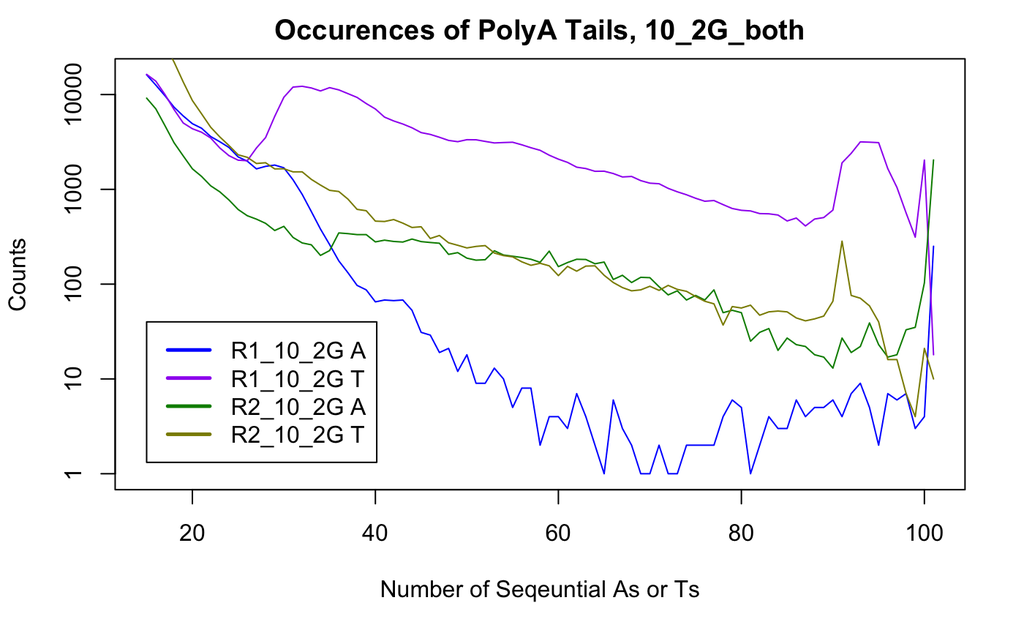

```r
legend(15,40,
       c("R1_10_2G A", "R1_10_2G T", "R2_10_2G A", "R2_10_2G T"),
       lty=c(1,1,1,1),
       lwd=c(2.5,2.5,2.5,2.5),
       col=c("blue", "purple", "green4", "yellow4"))
```

```r
plot(R1_17_3E_A$tail_len,
     R1_17_3E_A$V1,
     log = "y",
     col = "blue",
     type = "l",
     ylab = "Counts",
     xlab = "Number of Seqeuntial As or Ts",
     main = "Occurences of PolyA Tails, 17_3E_fox")
lines(R1_17_3E_T$tail_len, R1_17_3E_T$V1, type = "l", col = "purple")
```

```r
lines(R2_17_3E_A$tail_len, R2_17_3E_A$V1, type = "l", col = "green4")
lines(R2_17_3E_T$tail_len, R2_17_3E_T$V1, type = "l", col = "yellow4")
```

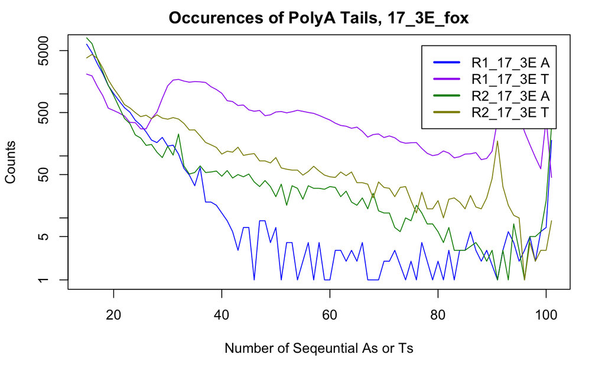

```r
legend(77,6000, c("R1_17_3E A", "R1_17_3E T", "R2_17_3E A", "R2_17_3E T"), lty=c(1,1,1,1), lwd=c(2.5,2.5,2.5,2.5),col=c("blue", "purple", "green4", "yellow4"))
```

```r
sums_17_R1 = c(sum(R1_17_3E_A$V1), sum(R1_17_3E_T$V1), sum(R2_17_3E_A$V1), sum(R2_17_3E_T$V1))
```

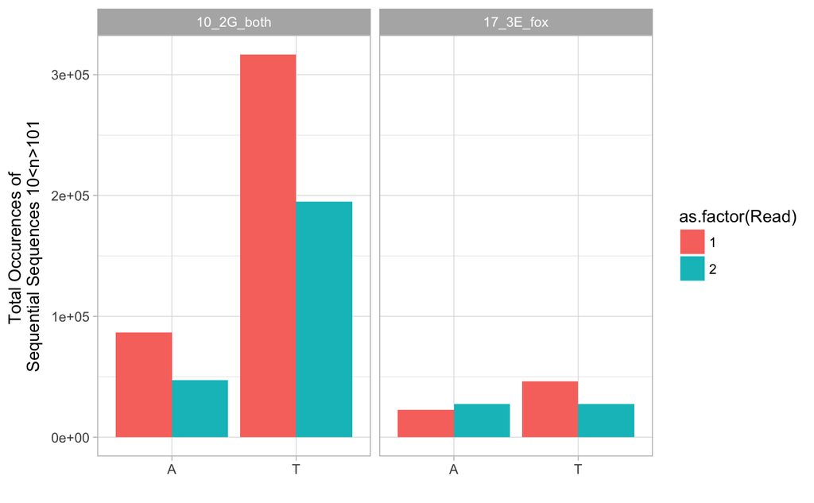

```r
library(tidyverse)
library(pander)
Read <- rep(c(1, 2), 4)
trt <- c(rep("10_2G_both", 4),rep("17_3E_fox", 4))
poly <- rep(c(rep("A", 2),rep("T", 2)), 2)
occurences <- c(sum(R1_10_2G_A$V1),
                sum(R2_10_2G_A$V1),
                sum(R1_10_2G_T$V1),
                sum(R2_10_2G_T$V1),
                sum(R1_17_3E_A$V1),
                sum(R2_17_3E_A$V1),
                sum(R1_17_3E_T$V1),
                sum(R2_17_3E_T$V1))
strd_table <- type_convert(as.tibble(cbind(Read, trt, poly, occurences)))
ggplot(strd_table,
       aes(poly, occurences, fill = as.factor(Read))) +
       geom_col(position = position_dodge()) +
       facet_grid(~trt) +
       labs(x = "", y = "Total Occurences of \nSequential Sequences 10<n>101") +
       theme_light()
```